# Ejercicios Sección I- XI

- Mostrar todo el código
- Ocultar todo el código
- Ver el código fuente

Bioinformática I

Autor/a

Alan Llano

# 3. Objetos y estructuras de datos en R

## Ejercicio 1. Vectores y selección

## Ejercicio 2: Factores

## Ejercicio 3. Elegir estructuras

## **Ejercicio 1. Vectores y selección**

Crea los vectores `ids <- c("g1", "g2", "g3", "g4", "g5")` y `tam <- c(90, 450, 310, 120, 600)`.

1. Selecciona el tercer identificador. **Respuesta: “g3”**
2. Recupera los identificadores de genes con longitud de al menos 300.

   **Respuesta: “g2” , “g3” , “g5”**
3. Cuenta cuántos cumplen esa condición sin usar un ciclo. **Respuesta: 3**

**Código**

```r
ids <- c("g1", "g2", "g3", "g4", "g5")
tam <- c(90, 450, 310, 120, 600)
ids[3] #Tercer identificador.
```

```
[1] "g3"
```

**Código**

```r
ids[tam >= 300] #Recupera los identificadores de genes con longitud de al menos 300.
```

```
[1] "g2" "g3" "g5"
```

**Código**

```r
sum(tam >= 300) #Cuenta cuántos cumplen esa condición sin usar un ciclo
```

```
[1] 3
```

## **Ejercicio 2: Factores**

Crea una vector con las letras `A M A B M M B A B B`, donde `A` significa Alto, `B` bajo y `M` medio. Convierte las entradas del vector a factores y especifica que `A > M > B`.

`ordered = TRUE` le indica a R que las categorías de tu factor tienen una **jerarquía**

**Código**

```r
vector_ABM <- factor(c("A","M","A","B","M","M","B","A","B","B"),
                     levels = c("B", "M", "A"),
                     labels = c("Bajo", "Medio", "Alto"),
                     ordered = TRUE)


levels(vector_ABM)
```

```
[1] "Bajo"  "Medio" "Alto"
```

## **Ejercicio 3. Elegir estructuras**

1. Construye un `data.frame` con tres genes, sus longitudes y una etiqueta funcional.
2. Recupera únicamente las filas con longitud mayor que 200.
3. Crea una lista que contenga la tabla y el identificador de una muestra.
4. Explica por qué una matriz de caracteres no sería una buena sustitución para la tabla cuando queremos conservar longitudes numéricas.

**Código**

```r
anotaciones <- data.frame(
  gen = c("Hox1", "Hox2", "Hox3"),
  longitud = c(25, 300, 1000),
  tagmas = c("Pedipalpo", "Prosoma", "Opistoma")
)

anotaciones$longitud >= 200
```

```
[1] FALSE  TRUE  TRUE
```

**Código**

```r
anotaciones
```

```
   gen longitud    tagmas
1 Hox1       25 Pedipalpo
2 Hox2      300   Prosoma
3 Hox3     1000  Opistoma
```

**Código**

```r
resultado <- list(muestra = "M01", genes = anotaciones)
resultado$genes
```

```
   gen longitud    tagmas
1 Hox1       25 Pedipalpo
2 Hox2      300   Prosoma
3 Hox3     1000  Opistoma
```

Una matriz en R es una estructura “homogénea”, osea todos sus elementos deben ser exactamente del mismo tipo de dato. Si guardas datos mixtos (como nombres de genes o secuencias junto con sus longitudes) en una matriz, R aplica **coerción automática** y convierte todos los números en texto (`character`), lo que arruina su comportamiento numérico.

# 4. Estructuras de control

## Ejercicio 4. Clasificación de un valor

## Ejercicio 5. Verificación de conteos

## Ejercicio 6. Longitudes de secuencias

## Ejercicio 7. Alcanzar una longitud

## **Ejercicio 4. Clasificación de un valor**

Define una variable `conteo` que represente el número de lecturas asignadas a un gen. Escribe un condicional que imprima:

- `"Dato faltante"` si el valor es `NA`.
- `"Conteo inválido"` si es negativo.
- `"Sin lecturas"` si es cero.
- `"Con lecturas"` si es positivo.

Prueba tu código con `NA`, `-2`, `0` y `15`.

**Código**

```r
conteo <- NA

if (is.na(conteo)) {
  print("Dato faltante")
} else {
  if (conteo < 0) {
    print("Conteo inválido")
  } else if (conteo > 0) {
    print("Con lecturas")
  } else {
    print("Sin lecturas")
  }
}
```

```
[1] "Dato faltante"
```

**Código**

```r
conteo <- -2

if (is.na(conteo)) {
  print("Dato faltante")
} else {
  if (conteo < 0) {
    print("Conteo inválido")
  } else if (conteo > 0) {
    print("Con lecturas")
  } else {
    print("Sin lecturas")
  }
}
```

```
[1] "Conteo inválido"
```

**Código**

```r
conteo <- 0

if (is.na(conteo)) {
  print("Dato faltante")
} else {
  if (conteo < 0) {
    print("Conteo inválido")
  } else if (conteo > 0) {
    print("Con lecturas")
  } else {
    print("Sin lecturas")
  }
}
```

```
[1] "Sin lecturas"
```

**Código**

```r
conteo <- 15

if (is.na(conteo)) {
  print("Dato faltante")
} else {
  if (conteo < 0) {
    print("Conteo inválido")
  } else if (conteo > 0) {
    print("Con lecturas")
  } else {
    print("Sin lecturas")
  }
}
```

```
[1] "Con lecturas"
```

## **Ejercicio 5. Verificación de conteos**

Considera el vector `conteos <- c(8, 0, 13, 5, 0, 21)`. Utiliza las funciones anteriores para:

1. Verificar si todos los valores son no negativos.
2. Determinar si existe al menos un conteo mayor que 20.
3. Obtener las posiciones de los conteos iguales a cero.
4. Crear un vector que indique `"Presente"` o `"Ausente"` según si el conteo es mayor que cero.

**Código**

```r
conteos <- c(8, 0, 13, 5, 0, 21)
estado <- ifelse(conteos >= 0, "Positivo", "Negativo")
estado
```

```
[1] "Positivo" "Positivo" "Positivo" "Positivo" "Positivo" "Positivo"
```

**Código**

```r
conteos <- c(8, 0, 13, 5, 0, 21)
estado <- ifelse(conteos > 20, "Positivo", "Negativo")
estado
```

```
[1] "Negativo" "Negativo" "Negativo" "Negativo" "Negativo" "Positivo"
```

**Código**

```r
which(conteos == 0)
```

```
[1] 2 5
```

**Código**

```r
conteos <- c(8, 0, 13, 5, 0, 21)
estado <- ifelse(conteos > 0, "Presente", "Ausente")
estado
```

```
[1] "Presente" "Ausente"  "Presente" "Presente" "Ausente"  "Presente"
```

## **Ejercicio 6. Longitudes de secuencias**

A partir del vector:

Código

```
secuencias <- c("ATG", "ATGCGT", "AATTCCGG", "CG")
```

1. Utiliza un ciclo `for` para guardar las longitudes en un vector llamado `longitudes`.
2. Crea otro vector llamado `clasificacion` que contenga `"Corta"` para longitudes menores que 5 y `"Larga"` para longitudes de al menos 5.
3. Muestra ambos vectores.

**Código**

```r
secuencias <- c("ATG", "ATGCGT", "AATTCCGG", "CG")
longitudes <- numeric(length(secuencias))

for (i in seq_along(secuencias)) {
longitudes[i] <- nchar(secuencias[i])
}

longitudes
```

```
[1] 3 6 8 2
```

**Código**

```r
secuencias <- c("ATG", "ATGCGT", "AATTCCGG", "CG")

clasificacion <- character(length(secuencias))

for (i in seq_along(secuencias)) {
  longitudes[i] <- nchar(secuencias[i])

  if (longitudes[i] < 5) {
    clasificacion[i] <- "Corta"
  } else {
    clasificacion[i] <- "Larga"
  }
}
clasificacion
```

```
[1] "Corta" "Larga" "Larga" "Corta"
```

## Ejercicio 7. Alcanzar una longitud

Imagina que estamos construyendo una secuencia mediante la adición de un nucleótido “A” en cada iteración. Escribe un ciclo while que comience con una cadena vacía y se detenga cuando la secuencia alcance 8 nucleótidos. Muestra el resultado final.

**Código**

```r
limite <- 9
secuencia <- ""
while (nchar(secuencia) < 8) {
  secuencia <- paste0(secuencia, "A")
}
secuencia
```

```
[1] "AAAAAAAA"
```

# 5. Funciones en R

## Ejercicio 8: Función 1

## Ejercicio 9: Función 2

## Ejercicio 10: Función 3

## 5.6 Actividad Final (Ejercicio 11)

## Ejercicio 8: Función 1

Escribe una función llamada `empieza_con` que reciba una secuencia y un prefijo, y determine si la secuencia comienza con ese prefijo. Pruébala con “ATGCGT” y los prefijos “ATG” y “TGA”.

**Código**

```r
empieza_con <- function(secuencia, prefijo) {
  startsWith(secuencia, prefijo)
}
empieza_con("ATGCGT", "ATG")
```

```
[1] TRUE
```

**Código**

```r
empieza_con("ATGCGT", "TGA")
```

```
[1] FALSE
```

## Ejercicio 9: Función 2

Modifica `resumir_adn()` para que también devuelva la proporción de nucleótidos G y C respecto de la longitud total. Prueba la función con una secuencia no vacía.

**Código**

```r
resumir_adn <- function(id, secuencia) {
  secuencia <- toupper(secuencia)
  bases <- strsplit(secuencia, split = "", fixed = TRUE)[[1]]
  longitud <- nchar(secuencia)
  conteo_gc <- sum(bases %in% c("G", "C"))
  proporcion_gc <- conteo_gc / longitud
  list(
    id = id,
    longitud = longitud,
    conteo_gc = conteo_gc,
    proporcion_gc = proporcion_gc
  )
}
resultado <- resumir_adn("GEN_01", "ATGCGTAA")
resultado
```

```
$id
[1] "GEN_01"

$longitud
[1] 8

$conteo_gc
[1] 3

$proporcion_gc
[1] 0.375
```

## Ejercicio 10: Función 3

Crea una función llamada `clasificar_secuencias` que reciba un vector de secuencias y devuelva una lista con dos elementos:

validas: las secuencias formadas únicamente por A, C, G y T.

invalidas: las secuencias que contienen otros caracteres o valores faltantes.

Utiliza la función `revisar_secuencias()` del ejemplo anterior.

**Código**

```r
revisar_secuencias <- function(secuencias) {
  resultado <- logical(length(secuencias))
  for (i in seq_along(secuencias)) {
    secuencia <- secuencias[i]
    if (is.na(secuencia)) {
      resultado[i] <- FALSE
    } else {
      resultado[i] <- grepl("^[ACGT]+$", toupper(secuencia))
    }
  }
  resultado
}

clasificar_secuencias <- function(secuencias) {
  #Verifica que el argumento recibido sea un vector de tipo carácter.
  stopifnot(is.character(secuencias))
  #Utiliza la función revisar_secuencias() para identificar
  #cuáles secuencias son válidas y guarda los resultados.
  es_valida <- revisar_secuencias(secuencias)
  list(
    validas = secuencias[es_valida],
    invalidas = secuencias[!es_valida]
  )
}
clasificar_secuencias(c("ATGCGT", "ACNTGA", "ttacga", NA))
```

```
$validas
[1] "ATGCGT" "ttacga"

$invalidas
[1] "ACNTGA" NA
```

## Ejercicio 11

Un archivo de secuencias ha sido representado en R mediante dos vectores:

`ids <- c("seq_01", "seq_02", "seq_03", "seq_04")` `secuencias <- c("ATGCGT", "ACNTGA", "GGCCAA", "TTTAAA")`

Escribe una función `crear_reporte_secuencias(ids, secuencias)` que:

Compruebe que ambos argumentos son vectores de caracteres y tienen la misma longitud.

Identifique las secuencias válidas mediante `revisar_secuencias()`.

Devuelva un data.frame con las columnas id, secuencia, longitud y valida.

Asigne NA a la longitud de las secuencias inválidas.

**Código**

```r
crear_reporte_secuencias <- function(ids, secuencias) {
  # Comprobar que ambos son vectores de caracteres y tienen la misma longitud
  stopifnot(
    is.character(ids),
    is.character(secuencias),
    length(ids) == length(secuencias)
  )
  #Identificar secuencias válidas
  es_valida <- revisar_secuencias(secuencias)
  #Calcular longitud y asignar NA a las inválidas
  longitudes <- ifelse(es_valida, nchar(secuencias), NA)
  #Devolver el data.frame con las 4 columnas
  data.frame(
    id = ids,
    secuencia = secuencias,
    longitud = longitudes,
    valida = es_valida
  )
}
ids <- c("seq_01", "seq_02", "seq_03", "seq_04")
secuencias <- c("ATGCGT", "ACNTGA", "GGCCAA", "TTTAAA")
crear_reporte_secuencias(ids, secuencias)
```

```
      id secuencia longitud valida
1 seq_01    ATGCGT        6   TRUE
2 seq_02    ACNTGA       NA  FALSE
3 seq_03    GGCCAA        6   TRUE
4 seq_04    TTTAAA        6   TRUE
```

# 6. Scripts, paquetes y proyectos de RStudio

## 6.5 Ejercicio 1 (Ejercicio 12)

## Ejercicio 12

Considera el siguiente código, guardado en un archivo llamado `revision.R`:

**Código**

```r
longitudes <- nchar(secuencias)
resultado <- data.frame(id = ids, longitud = longitudes)
print(resultado)
```

```
      id longitud
1 seq_01        6
2 seq_02        6
3 seq_03        6
4 seq_04        6
```

Un estudiante afirma que el archivo funciona porque obtuvo una tabla al ejecutarlo en su computadora.

¿Por qué podría fallar si otra persona abre el archivo y lo ejecuta desde una sesión nueva de R?

Esta utilizando dos objetos (secuencias e ids) que nunca se crean ni se cargan dentro de revision.R. Probablemente obtuvo la tabla porque esas variables ya existían en su entorno global de haberlas creado anteriormente.

¿Cómo se puede modificar el script para que pueda ejecutarse completo sin depender de objetos creados previamente en la consola?

Cargamos los datos de entrada al inicio del archivo, de dos maneras:

1. Definimos los vectores directamente en el script.
2. Los leemos desde un archivo externo como un .csv o .tsv del proyecto, incluyendo su ruta.

# 7. Importación y exploración de datos bioinformáticos en R

## 7.3.2 Ejercicio 1: Reconocer un archivo antes de importarlo (Ejercicio 13)

## 7.4 Ejercicio 2: Elegir la función adecuada (Ejercicio 14)

## 7.5 Ejercicio 3: Explorar resultados tipo BLAST (Ejercicio 15)

## 7.6 Ejercicio 4: Detectar un problema de lectura (Ejercicio 16)

## 7.7 Ejercicio 5: Reconocer secuencias en FASTA (Ejercicio 17)

## 7.8 Práctica Final - Ejercicio 6: De los archivos a una descripción de los datos (Ejercicio 18)

## Ejercicio 13: Reconocer un archivo antes de importarlo

Sin abrirlo en una hoja de cálculo, utiliza R para comprobar que existe `blast_separador_incorrecto.csv`, mostrar sus tres primeras líneas y determinar qué separador utiliza realmente.

**Código**

```r
file.exists("~/P3_Intro_Bioinfo/data_raw/datos_sesion_02_blast/blast_separador_incorrecto.csv")
```

```
[1] TRUE
```

**Código**

```r
readLines("~/P3_Intro_Bioinfo/data_raw/datos_sesion_02_blast/blast_separador_incorrecto.csv", n = 5)
```

```
[1] "query_id\tsubject_id\tpident\tlength\tevalue\tbitscore"
[2] "seq01\tref_001\t87.9\t216\t1.00e-40\t118.7"
[3] "seq01\tref_002\t68.2\t245\t1.00e-36\t184.6"
[4] "seq01\tref_003\t93.5\t168\t1.00e-35\t386.1"
[5] "seq02\tref_004\t82.6\t111\t1.00e-85\t259.9"
```

## Ejercicio 14: Elegir la función adecuada

Importa `metadata_secuencias.csv` y `blast_comentarios.tsv` utilizando readr. Conserva `codigo_muestra` como texto. Comprueba la clase de cada objeto y muestra sus primeras filas.

**Código**

```r
library(readr)
metadata <- read_csv(
  "~/P3_Intro_Bioinfo/data_raw/datos_sesion_02_blast/metadata_secuencias.csv",
  col_types = cols(codigo_muestra = col_character()),
  show_col_types = FALSE
)
blast_comentarios <- read_tsv(
  "~/P3_Intro_Bioinfo/data_raw/datos_sesion_02_blast/blast_comentarios.tsv",
  comment = "#",
  show_col_types = FALSE
)
class(metadata)
```

```
[1] "spec_tbl_df" "tbl_df"      "tbl"         "data.frame"
```

**Código**

```r
class(blast_comentarios)
```

```
[1] "spec_tbl_df" "tbl_df"      "tbl"         "data.frame"
```

**Código**

```r
head(metadata)
```

```
# A tibble: 6 × 4
  query_id organismo  origen codigo_muestra
  <chr>    <chr>      <chr>  <chr>
1 seq01    Bacteria_A suelo  001
2 seq02    Bacteria_B agua   002
3 seq03    Bacteria_C suelo  003
4 seq04    Bacteria_A agua   004
5 seq05    Bacteria_B suelo  005
6 seq06    Bacteria_C agua   006
```

**Código**

```r
head(blast_comentarios)
```

```
# A tibble: 6 × 6
  query_id subject_id pident length evalue bitscore
  <chr>    <chr>       <dbl>  <dbl>  <dbl>    <dbl>
1 seq01    ref_001      87.9    216  1e-40     119.
2 seq01    ref_002      68.2    245  1e-36     185.
3 seq01    ref_003      93.5    168  1e-35     386.
4 seq02    ref_004      82.6    111  1e-85     260.
5 seq02    ref_005      68.7    292  1e-57     323.
6 seq03    ref_007      88.2    254  1e- 5     362.
```

## Ejercicio 15: Explorar resultados tipo BLAST

Con `resultados_blast.tsv`, responde mediante código:

¿Cuántos registros y columnas tiene la tabla? 20 registros y 6 columnas

¿Cuántos `query_id` diferentes aparecen? 8

¿Cuántos resultados tiene cada consulta? seq01: 3, seq02: 2, seq03: 4, seq04: 1, seq05: 3, seq06: 2, seq07: 3, seq08: 2

¿Qué filas tienen `pident` mayor o igual a 95? seq_03 y seq_07

¿Hay valores faltantes? No

**Código**

```r
library(readr)
# Importar la tabla
blast <- read_tsv(
  "~/P3_Intro_Bioinfo/data_raw/datos_sesion_02_blast/resultados_blast.tsv",
  show_col_types = FALSE
)
dim(blast)
```

```
[1] 20  6
```

**Código**

```r
nrow(blast)
```

```
[1] 20
```

**Código**

```r
ncol(blast)
```

```
[1] 6
```

**Código**

```r
length(unique(blast$query_id))
```

```
[1] 8
```

**Código**

```r
table(blast$query_id)
```

```
seq01 seq02 seq03 seq04 seq05 seq06 seq07 seq08
    3     2     4     1     3     2     3     2
```

**Código**

```r
blast[blast$pident >= 95, ]
```

```
# A tibble: 3 × 6
  query_id subject_id pident length evalue bitscore
  <chr>    <chr>       <dbl>  <dbl>  <dbl>    <dbl>
1 seq03    ref_009      97.8    191  1e-71     97.9
2 seq03    ref_010      99      229  1e- 8    336.
3 seq07    ref_019      95.7    106  1e-70    138.
```

**Código**

```r
anyNA(blast)
```

```
[1] FALSE
```

**Código**

```r
colSums(is.na(blast))
```

```
  query_id subject_id     pident     length     evalue   bitscore
         0          0          0          0          0          0
```

## Ejercicio 16: Detectar un problema de lectura

Un estudiante importa `blast_separador_incorrecto.csv` con `read_csv()` y obtiene una sola columna. ¿Significa que el archivo contiene una única variable? Explica cómo comprobarlo y corrige la importación.

No, lo que nos dice es que el separador real del archivo no coincide con el que espera la función, aunque el archivo tiene extensión .csv, sus columnas están separadas por tabulaciones ( y no por comas. Al usar `read_csv()`, R busca comas, no encuentra ninguna y junta toda la fila en una sola columna de texto.

Podemos ocupar `readLines()` para comprobar

No es necesario renombrar el archivo; podemos usar `read_tsv()` (o `read_delim(..., delim = "\t")`) para indicarle a readr que el separador es un tabulador.

**Código**

```r
library(readr)
ruta <- "~/P3_Intro_Bioinfo/data_raw/datos_sesion_02_blast/blast_separador_incorrecto.csv"
# 1. Comprobar el formato real del archivo
readLines(ruta, n = 3)
```

```
[1] "query_id\tsubject_id\tpident\tlength\tevalue\tbitscore"
[2] "seq01\tref_001\t87.9\t216\t1.00e-40\t118.7"
[3] "seq01\tref_002\t68.2\t245\t1.00e-36\t184.6"
```

**Código**

```r
# (Opcional) Ver cómo queda mal importado con read_csv()
mal <- read_csv(ruta, show_col_types = FALSE)
names(mal)
```

```
[1] "query_id\tsubject_id\tpident\tlength\tevalue\tbitscore"
```

**Código**

```r
# Devuelve: "query_id\tsubject_id\tpident\tlength\tevalue\tbitscore"
# 2. Corregir la importación con la función adecuada para tabulaciones
bien <- read_tsv(ruta, show_col_types = FALSE)
# 3. Verificar que ahora sí tiene las 6 columnas separadas
names(bien)
```

```
[1] "query_id"   "subject_id" "pident"     "length"     "evalue"
[6] "bitscore"
```

**Código**

```r
dim(bien)
```

```
[1] 20  6
```

**Código**

```r
head(bien)
```

```
# A tibble: 6 × 6
  query_id subject_id pident length evalue bitscore
  <chr>    <chr>       <dbl>  <dbl>  <dbl>    <dbl>
1 seq01    ref_001      87.9    216  1e-40     119.
2 seq01    ref_002      68.2    245  1e-36     185.
3 seq01    ref_003      93.5    168  1e-35     386.
4 seq02    ref_004      82.6    111  1e-85     260.
5 seq02    ref_005      68.7    292  1e-57     323.
6 seq03    ref_007      88.2    254  1e- 5     362.
```

## Ejercicio 17: Reconocer secuencias en FASTA

Utiliza `readLines()` y `grep()` para identificar los encabezados de `secuencias.fasta`. ¿Cuántas entradas FASTA contiene el archivo? Muestra únicamente sus encabezados.

**Código**

```r
lineas <- readLines("~/P3_Intro_Bioinfo/data_raw/datos_sesion_02_blast/secuencias.fasta")
encabezados <- grep("^>", lineas, value = TRUE)
length(encabezados)
```

```
[1] 8
```

**Código**

```r
encabezados
```

```
[1] ">seq01 secuencia_sintetica" ">seq02 secuencia_sintetica"
[3] ">seq03 secuencia_sintetica" ">seq04 secuencia_sintetica"
[5] ">seq05 secuencia_sintetica" ">seq06 secuencia_sintetica"
[7] ">seq07 secuencia_sintetica" ">seq08 secuencia_sintetica"
```

## Ejercicio 18: De los archivos a una descripción de los datos

Crea un script llamado `02_exploracion.R` dentro de tu proyecto. El script debe:

Comprobar que existen `resultados_blast.tsv`, `metadata_secuencias.csv` y `secuencias.fasta`.

Importar las dos tablas con readr y conservar `codigo_muestra` como texto.

Mostrar dimensiones, nombres y tipos de columnas.

Identificar los `query_id` distintos y contar los resultados por consulta.

Mostrar las filas con `pident >= 90` y explicar qué representa este filtro.

Leer el FASTA e indicar cuántos encabezados contiene.

Mostrar si alguna de las tablas tiene valores faltantes.

Escribe al final del script, como comentarios, tres observaciones sobre la estructura de los datos, sin extraer conclusiones biológicas.

**Código**

```r
library(readr)
# Definir la carpeta base donde se encuentran los archivos
ruta_base <- "~/P3_Intro_Bioinfo/data_raw/datos_sesion_02_blast"
ruta_blast    <- file.path(ruta_base, "resultados_blast.tsv")
ruta_metadata <- file.path(ruta_base, "metadata_secuencias.csv")
ruta_fasta    <- file.path(ruta_base, "secuencias.fasta")

#Comprobar que existen los tres archivos
file.exists(ruta_blast)
```

```
[1] TRUE
```

**Código**

```r
file.exists(ruta_metadata)
```

```
[1] TRUE
```

**Código**

```r
file.exists(ruta_fasta)
```

```
[1] TRUE
```

**Código**

```r
#Importar las dos tablas con readr (codigo_muestra como texto)
blast <- read_tsv(
  ruta_blast,
  show_col_types = FALSE
)
metadata <- read_csv(
  ruta_metadata,
  col_types = cols(codigo_muestra = col_character()),
  show_col_types = FALSE
)

#Mostrar dimensiones, nombres y tipos de columnas
# Tabla BLAST
dim(blast)
```

```
[1] 20  6
```

**Código**

```r
names(blast)
```

```
[1] "query_id"   "subject_id" "pident"     "length"     "evalue"
[6] "bitscore"
```

**Código**

```r
str(blast)
```

```
spc_tbl_ [20 × 6] (S3: spec_tbl_df/tbl_df/tbl/data.frame)
 $ query_id  : chr [1:20] "seq01" "seq01" "seq01" "seq02" ...
 $ subject_id: chr [1:20] "ref_001" "ref_002" "ref_003" "ref_004" ...
 $ pident    : num [1:20] 87.9 68.2 93.5 82.6 68.7 88.2 93.6 97.8 99 83.9 ...
 $ length    : num [1:20] 216 245 168 111 292 254 319 191 229 162 ...
 $ evalue    : num [1:20] 1e-40 1e-36 1e-35 1e-85 1e-57 ...
 $ bitscore  : num [1:20] 119 185 386 260 323 ...
 - attr(*, "spec")=
  .. cols(
  ..   query_id = col_character(),
  ..   subject_id = col_character(),
  ..   pident = col_double(),
  ..   length = col_double(),
  ..   evalue = col_double(),
  ..   bitscore = col_double()
  .. )
 - attr(*, "problems")=<pointer: 0x7706d440e0>
```

**Código**

```r
# Tabla Metadata
dim(metadata)
```

```
[1] 8 4
```

**Código**

```r
names(metadata)
```

```
[1] "query_id"       "organismo"      "origen"         "codigo_muestra"
```

**Código**

```r
str(metadata)
```

```
spc_tbl_ [8 × 4] (S3: spec_tbl_df/tbl_df/tbl/data.frame)
 $ query_id      : chr [1:8] "seq01" "seq02" "seq03" "seq04" ...
 $ organismo     : chr [1:8] "Bacteria_A" "Bacteria_B" "Bacteria_C" "Bacteria_A" ...
 $ origen        : chr [1:8] "suelo" "agua" "suelo" "agua" ...
 $ codigo_muestra: chr [1:8] "001" "002" "003" "004" ...
 - attr(*, "spec")=
  .. cols(
  ..   query_id = col_character(),
  ..   organismo = col_character(),
  ..   origen = col_character(),
  ..   codigo_muestra = col_character()
  .. )
 - attr(*, "problems")=<pointer: 0x7706d44050>
```

**Código**

```r
#Identificar query_id distintos y contar resultados por consulta
unique(blast$query_id)
```

```
[1] "seq01" "seq02" "seq03" "seq04" "seq05" "seq06" "seq07" "seq08"
```

**Código**

```r
length(unique(blast$query_id))
```

```
[1] 8
```

**Código**

```r
# Conteo de registros por cada query_id (ordenado de mayor a menor)
sort(table(blast$query_id), decreasing = TRUE)
```

```
seq03 seq01 seq05 seq07 seq02 seq06 seq08 seq04
    4     3     3     3     2     2     2     1
```

**Código**

```r
# Mostrar las filas con pident >= 90 y explicar qué representa el filtro
blast_pident_90 <- blast[blast$pident >= 90, ]
blast_pident_90
```

```
# A tibble: 5 × 6
  query_id subject_id pident length evalue bitscore
  <chr>    <chr>       <dbl>  <dbl>  <dbl>    <dbl>
1 seq01    ref_003      93.5    168  1e-35    386.
2 seq03    ref_008      93.6    319  1e-36     96.6
3 seq03    ref_009      97.8    191  1e-71     97.9
4 seq03    ref_010      99      229  1e- 8    336.
5 seq07    ref_019      95.7    106  1e-70    138.
```

**Código**

```r
#Leer el FASTA e indicar cuántos encabezados contiene
lineas_fasta <- readLines(ruta_fasta)
encabezados  <- grep("^>", lineas_fasta, value = TRUE)
length(encabezados)
```

```
[1] 8
```

**Código**

```r
encabezados
```

```
[1] ">seq01 secuencia_sintetica" ">seq02 secuencia_sintetica"
[3] ">seq03 secuencia_sintetica" ">seq04 secuencia_sintetica"
[5] ">seq05 secuencia_sintetica" ">seq06 secuencia_sintetica"
[7] ">seq07 secuencia_sintetica" ">seq08 secuencia_sintetica"
```

**Código**

```r
#Mostrar si alguna de las tablas tiene valores faltantes (NA)
anyNA(blast)
```

```
[1] FALSE
```

**Código**

```r
colSums(is.na(blast))
```

```
  query_id subject_id     pident     length     evalue   bitscore
         0          0          0          0          0          0
```

**Código**

```r
anyNA(metadata)
```

```
[1] FALSE
```

**Código**

```r
colSums(is.na(metadata))
```

```
      query_id      organismo         origen codigo_muestra
             0              0              0              0
```

**Código**

```r
# Observaciones sobre la estructura de los datos:
# 1. Hay 8 secuencias en el FASTA, 8 filas en metadata y los mismos 8 query_id en la tabla BLAST.
# 2. Ninguna tabla tiene datos faltantes (NA).
# 3. De los 20 registros de BLAST, solo 5 tienen pident >= 90.
```

# 8. Manipulación y transformación de datos bioinformáticos con dplyr y tidyr

## 8.10.1 Ejercicio 19. Identificación de genes candidatos (Ejercicio 19)

## 8.10.2 Ejercicio 20. ¿Qué funciones biológicas predominan? (Ejercicio 20)

## Ejercicio 19. Identificación de genes candidatos

Queremos explorar qué genes podrían estar relacionados con la respuesta bacteriana al estrés.

Utilizando dplyr:

Calcula el conteo promedio de cada gen en cada condición experimental.

Organiza los resultados de manera que puedas comparar los promedios de Control y Estrés para cada gen.

Calcula la razón entre el promedio en Estrés y el promedio en Control.

Identifica los cinco genes con mayor aumento relativo y muestra su anotación funcional.

Pregunta de interpretación: ¿Un gen con un aumento relativo grande necesariamente presenta un conteo alto de lecturas? Justifica tu respuesta.

**Código**

```r
library(readr)
library(dplyr)
library(tidyr)

datos <- read_csv(
  "data_raw/expresion_genica_estres.csv",
  show_col_types = FALSE
)
glimpse(datos)
```

```
Rows: 240
Columns: 8
$ sample_id     <chr> "CTL_01", "CTL_02", "CTL_03", "EST_01", "EST_02", "EST_0…
$ condicion     <chr> "Control", "Control", "Control", "Estres", "Estres", "Es…
$ replica       <dbl> 1, 2, 3, 1, 2, 3, 1, 2, 3, 1, 2, 3, 1, 2, 3, 1, 2, 3, 1,…
$ gene_id       <chr> "gene_001", "gene_001", "gene_001", "gene_001", "gene_00…
$ funcion       <chr> "Función desconocida", "Función desconocida", "Función d…
$ longitud_pb   <dbl> 1803, 1803, 1803, 1803, 1803, 1803, 891, 891, 891, 891, …
$ gc_porcentaje <dbl> 58.1, 58.1, 58.1, 58.1, 58.1, 58.1, 43.2, 43.2, 43.2, 43…
$ conteo        <dbl> 1302, 1263, 1368, 892, 953, 1106, 639, 998, 1108, 733, 9…
```

**Código**

```r
library(dplyr)
library(tidyr)

top5_estres <- datos %>%
  #Conteo promedio de cada gen por condición
  group_by(gene_id, funcion, condicion) %>%
  summarise(
    promedio = mean(conteo),
    .groups = "drop"
  ) %>%
  #Formato ancho para comparar Control vs. Estres
  pivot_wider(
    names_from = condicion,
    values_from = promedio
  ) %>%
  #Razón Estrés / Control
  mutate(
    razon_estres_control = Estres / Control
  ) %>%
  # Top 5 genes con mayor aumento relativo
  slice_max(order_by = razon_estres_control, n = 5)

top5_estres
```

```
# A tibble: 5 × 5
  gene_id  funcion                  Control Estres razon_estres_control
  <chr>    <chr>                      <dbl>  <dbl>                <dbl>
1 gene_009 Transporte de membrana      179.  1162.                 6.50
2 gene_029 Metabolismo energético      237.  1318.                 5.57
3 gene_039 Metabolismo energético      312   1717.                 5.50
4 gene_028 Replicación y reparación    452   2127.                 4.71
5 gene_019 Transporte de membrana      868.  4020.                 4.63
```

Pregunta de interpretación: ¿Un gen con un aumento relativo grande necesariamente presenta un conteo alto de lecturas? Justifica tu respuesta.

`gene_009` tiene el mayor aumento relativo (6.50), pero es el que tiene los conteos absolutos más bajos de todo el top 5.

`gene_019` quedó en quinto lugar en aumento relativo (4.62), pero su nivel absoluto de expresión en estrés (4,019 lecturas) es mucho mas grande que el de `gene_009`.

Por lo tanto no podemos decir que un gen con un aumento relativo grande necesariamente presenta un conteo alto de lecturas.

## Ejercicio 20. ¿Qué funciones biológicas predominan?

Queremos investigar cuáles son las funciones biológicas representadas entre los genes con mayores conteos de lecturas.

Utilizando dplyr:

Calcula el conteo promedio de cada gen considerando todas las muestras.

Identifica los 15 genes con mayor conteo promedio.

Determina cuántos de esos genes pertenecen a cada categoría funcional.

Ordena las categorías funcionales de mayor a menor frecuencia.

Pregunta de interpretación: ¿La categoría funcional más frecuente entre estos 15 genes necesariamente es la más importante para la bacteria? Explica.

**Código**

```r
library(dplyr)

# Promedio y selección de los 15 mayores
top15_genes <- datos %>%
  group_by(gene_id, funcion) %>%
  summarise(
    promedio_global = mean(conteo),
    .groups = "drop"
  ) %>%
  slice_max(order_by = promedio_global, n = 15)

top15_genes
```

```
# A tibble: 15 × 3
   gene_id  funcion                    promedio_global
   <chr>    <chr>                                <dbl>
 1 gene_018 Metabolismo energético               2990.
 2 gene_008 Metabolismo energético               2548.
 3 gene_019 Transporte de membrana               2444
 4 gene_017 Replicación y reparación             1807.
 5 gene_026 Regulación transcripcional           1669.
 6 gene_036 Síntesis de proteínas                1585.
 7 gene_004 Síntesis de proteínas                1530.
 8 gene_023 Metabolismo de aminoácidos           1463.
 9 gene_007 Metabolismo energético               1456.
10 gene_006 Replicación y reparación             1451.
11 gene_024 Metabolismo de aminoácidos           1445.
12 gene_015 Regulación transcripcional           1410.
13 gene_028 Replicación y reparación             1290.
14 gene_032 Respuesta al estrés                  1240.
15 gene_001 Función desconocida                  1147.
```

**Código**

```r
# Contar cuántos genes hay por categoría y ordenar de mayor a menor
resumen_funciones <- top15_genes %>%
  count(funcion, sort = TRUE)

resumen_funciones
```

```
# A tibble: 8 × 2
  funcion                        n
  <chr>                      <int>
1 Metabolismo energético         3
2 Replicación y reparación       3
3 Metabolismo de aminoácidos     2
4 Regulación transcripcional     2
5 Síntesis de proteínas          2
6 Función desconocida            1
7 Respuesta al estrés            1
8 Transporte de membrana         1
```

Pregunta de interpretación: ¿La categoría funcional más frecuente entre estos 15 genes necesariamente es la más importante para la bacteria? Explica.

No, si vemos funciones como Metabolismo energético o Replicación y reparación que son las más frecuentes en el top 15, con 3 genes cada una, requieren muchas copias de ARNm de forma constante, mientras que genes igual de vitales como los de Regulación transcripcional o Respuesta al estrés cumplen su función con muchas menos lecturas.

# 9. Integración de datos y automatización de análisis en R

## 9.8 Actividad breve: ¿la tabla está lista para graficarse?

## Ejercicio 21

**Ejercicio**

Sin construir otra función, revisa `generos_5` y responde:

1. ¿Qué representa una fila de `generos_5`?

   Una combinación de muestra (`sample_id`), planta hospedera (`host_name`) y taxon (`taxon_final`), con su abundancia relativa.
2. ¿Por qué un mismo género puede aparecer individualmente en una muestra y dentro de `Otros` en otra?

   Porque el umbral del 5 % se aplica de forma independiente dentro de cada muestra y la proporción de cada género varía entre muestras.
3. Si construimos una gráfica de barras apiladas al 100 %, ¿cuánto deben sumar las abundancias relativas de cada muestra? Compruébalo con `group_by()` y `summarise()`. Debe dar la sua igual a uno.
4. ¿Qué columna nos permite comparar las muestras según la planta hospedera? ¿De dónde proviene?

   La columna `host_name`, que proviene de los metadatos (`metadata_rizosfera.csv`) integrados con `left_join()` mediante `sample_id`.

**Código**

```r
library(readr)
library(dplyr)

generos_5 <- read_tsv("results/generos_5.tsv", show_col_types = FALSE)

glimpse(generos_5)
```

```
Rows: 209
Columns: 4
$ sample_id           <chr> "ERR5639101", "ERR5639101", "ERR5639101", "ERR5639…
$ host_name           <chr> "Red pepper", "Red pepper", "Red pepper", "Red pep…
$ taxon_final         <chr> "Homo", "Otros", "Pasteurella", "Streptomyces", "B…
$ abundancia_relativa <dbl> 0.49705067, 0.36877708, 0.06713454, 0.06703771, 0.…
```

**Código**

```r
head(generos_5)
```

```
# A tibble: 6 × 4
  sample_id   host_name  taxon_final    abundancia_relativa
  <chr>       <chr>      <chr>                        <dbl>
1 ERR5639101  Red pepper Homo                        0.497
2 ERR5639101  Red pepper Otros                       0.369
3 ERR5639101  Red pepper Pasteurella                 0.0671
4 ERR5639101  Red pepper Streptomyces                0.0670
5 SRR11092499 Tomato     Bradyrhizobium              0.0647
6 SRR11092499 Tomato     Otros                       0.871
```

**Código**

```r
generos_5 %>%
  group_by(sample_id) %>%
  summarise(total = sum(abundancia_relativa), .groups = "drop")
```

```
# A tibble: 75 × 2
   sample_id   total
   <chr>       <dbl>
 1 ERR5639101  1
 2 SRR11092499 1.000
 3 SRR11092502 1.000
 4 SRR11092506 1.000
 5 SRR11092508 1.000
 6 SRR11092509 1.000
 7 SRR11092511 1
 8 SRR11092512 1.000
 9 SRR11128412 1.000
10 SRR11128413 1.000
# ℹ 65 more rows
```

# Construcción y exploración visual de datos bioinformáticos con ggplot2

## 10.12.1 Ejercicio 22

## 10.12.2 Ejercicio 23

### Ejercicio 22:

Utilizando `generos_5` y `metadata_riz`:

1. Identifica las plantas hospederas que tienen **al menos 5 muestras**.
2. Conserva únicamente las muestras correspondientes a esas plantas.
3. Construye una gráfica de barras apiladas de abundancia relativa por género con `ggplot2`, utilizando `facet_wrap()` para comparar las plantas hospederas.

Personaliza la figura con una paleta de colores adecuada, etiquetas legibles y la categoría `"Géneros < 5%"` al final de la leyenda.

**Para discutir:** ¿Qué diferencias observas en la composición taxonómica entre las plantas? ¿Todas las muestras de una misma planta presentan composiciones similares?

Se puede observan algunas diferencias en los géneros que superan el 5 % en cada planta hospedera , tales como en el porcentaje que ocupan la categoría < 5%.

No, aunque algunas muestras comparten géneros en común que abarcan mayor proprción, hay variabilidad entre muestras de una misma planta.

**Código**

```r
library(readr)
library(dplyr)
library(ggplot2)

generos_5 <- read_tsv("results/generos_5.tsv", show_col_types = FALSE)
metadata_riz <- read_csv("data_raw/datos_rizosfera/metadata_rizosfera.csv", show_col_types = FALSE)

#Identificar plantas hospederas con al menos 5 muestras
plantas_5 <- metadata_riz %>%
  count(host_name, name = "n_muestras") %>%
  filter(n_muestras >= 5) %>%
  pull(host_name)

plantas_5
```

```
[1] "Maize"     "Peanut"    "Soya bean" "Tomato"
```

**Código**

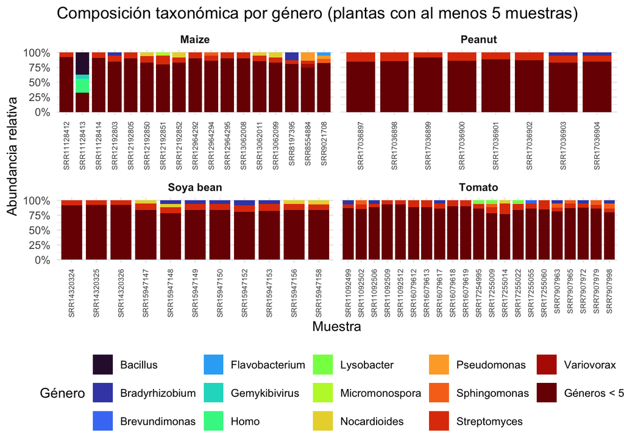

```r
# Conservar únicamente las muestras de esas plantas y asegurar la etiqueta "Géneros < 5%"
generos_filtrados <- generos_5 %>%
  filter(host_name %in% plantas_5) %>%
  mutate(
    taxon_final = if_else(taxon_final == "Otros", "Géneros < 5%", taxon_final)
  )

# Orden categorías para dejar "Géneros < 5%" al final de la leyenda
orden_generos <- c(
  sort(setdiff(unique(generos_filtrados$taxon_final), "Géneros < 5%")),
  "Géneros < 5%"
)

generos_filtrados <- generos_filtrados %>%
  mutate(taxon_final = factor(taxon_final, levels = orden_generos))

#  Gráfica de barras apiladas con facet_wrap() por planta hospedera
ggplot(
  generos_filtrados,
  aes(x = sample_id, y = abundancia_relativa, fill = taxon_final)
) +
  geom_col(width = 0.85) +
  facet_wrap(~ host_name, scales = "free_x") +
  scale_fill_viridis_d(option = "turbo", breaks = orden_generos) +
  scale_y_continuous(labels = function(x) paste0(round(100 * x), "%")) +
  labs(
    title = "Composición taxonómica por género (plantas con al menos 5 muestras)",
    x = "Muestra",
    y = "Abundancia relativa",
    fill = "Género"
  ) +
  theme_minimal(base_size = 11) +
  theme(
    axis.text.x = element_text(angle = 90, hjust = 1, vjust = 0.5, size = 6),
    strip.text = element_text(face = "bold"),
    legend.position = "bottom"
  )
```

### Ejercicio 23:

Utilizando `filos_5` y `metadata_riz`:

1. Identifica los países que tienen **al menos 5 muestras**.
2. Conserva únicamente las muestras correspondientes a esos países.
3. Construye una gráfica de barras apiladas de abundancia relativa por filo con `ggplot2`, utilizando `facet_wrap()` para comparar los países.

**Para discutir:** ¿Qué diferencias observas en la composición taxonómica entre los países? ¿Las muestras de un mismo país presentan composiciones similares?

Los filos como *Pseudomonadota* y *Actinomycetota* aparecen en la mayoría de los países, su porcetaje cambia entre paneles.

se puede observar variaciones dentro de estos mismos , como en el caso de Sudafrica.

**Código**

```r
library(readr)
library(dplyr)
library(ggplot2)
library(paletteer)

filos_5 <- read_tsv("results/filos_5.tsv", show_col_types = FALSE)
metadata_riz <- read_csv("data_raw/datos_rizosfera/metadata_rizosfera.csv", show_col_types = FALSE)

#Identificar los países que tienen al menos 5 muestras
paises_5 <- metadata_riz %>%
  count(country, name = "n_muestras") %>%
  filter(n_muestras >= 5) %>%
  pull(country)

paises_5
```

```
[1] "China"        "Mexico"       "Netherlands"  "South Africa"
```

**Código**

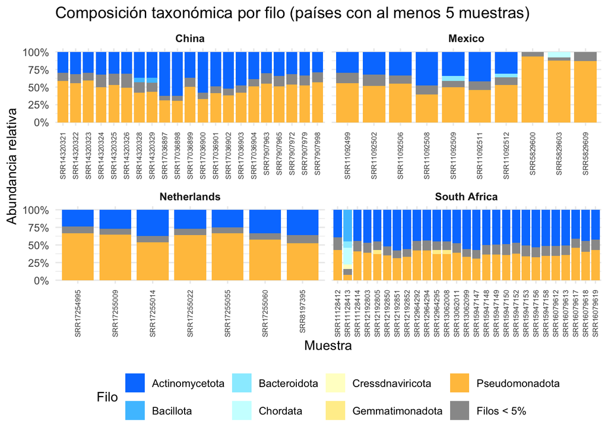

```r
# Incorporar el país desde metadata_riz y conservar solo esos países
filos_paises <- filos_5 %>%
  left_join(
    metadata_riz %>% select(sample_id, country),
    by = "sample_id",
    relationship = "many-to-one"
  ) %>%
  filter(country %in% paises_5)

#Ordenar filos para dejar "Filos < 5%" al final
orden_filos <- c(
  sort(setdiff(unique(filos_paises$taxon_final), "Filos < 5%")),
  "Filos < 5%"
)

colores <- as.character(
  paletteer::paletteer_d("colorBlindness::Blue2Orange8Steps")
)
colores <- c(colores[1:7], "#999999")

# Gráfica de barras apiladas con facet_wrap() por país
ggplot(
  filos_paises,
  aes(x = sample_id, y = abundancia_relativa, fill = taxon_final)
) +
  geom_col(width = 0.85) +
  facet_wrap(~ country, scales = "free_x") +
  scale_fill_manual(values = colores, breaks = orden_filos) +
  scale_y_continuous(labels = function(x) paste0(round(100 * x), "%")) +
  labs(
    title = "Composición taxonómica por filo (países con al menos 5 muestras)",
    x = "Muestra",
    y = "Abundancia relativa",
    fill = "Filo"
  ) +
  theme_minimal(base_size = 11) +
  theme(
    axis.text.x = element_text(angle = 90, hjust = 1, vjust = 0.5, size = 6),
    strip.text = element_text(face = "bold"),
    legend.position = "bottom"
  )
```